# Double Descent — laboratorium

Wersja konfigurowalna.

Notebook ma dwie części:

1. **Regresja w bazach wielomianowych**  
   Można łatwo zmieniać:
   - bazę wielomianów,
   - regularyzator.
2. **Sieć neuronowa o rosnącej liczbie parametrów**  
   Pokazuje wpływ overparameterization na train/test error.

Najważniejsza komórka to **KONFIGURACJA EKSPERYMENTU**.

```python
import numpy as np
import matplotlib.pyplot as plt
import time
import warnings

from sklearn.linear_model import LinearRegression, Ridge, Lasso, ElasticNet
from sklearn.metrics import mean_squared_error
from sklearn.preprocessing import StandardScaler

from numpy.polynomial.polynomial import polyvander
from numpy.polynomial.chebyshev import chebvander
from numpy.polynomial.legendre import legvander
from numpy.polynomial.hermite import hermvander
from numpy.polynomial.laguerre import lagvander

warnings.filterwarnings("ignore")

np.random.seed(42)

plt.rcParams["figure.figsize"] = (10, 6)
plt.rcParams["font.size"] = 13
```

# KONFIGURACJA EKSPERYMENTU

Tu studenci mogą zmieniać bazę i regularyzator.

## Dostępne bazy

```
"monomial"
"chebyshev"
"legendre"
"hermite"
"laguerre"
```

Najbezpieczniejsze dydaktycznie:

- `"chebyshev"`
- `"legendre"`

Laguerre naturalnie działa dla (x \ge 0), więc w tym notebooku automatycznie przeskalowujemy (x) z ([-1,1]) do ([0,1]).

## Dostępne regularyzatory

```
"least_squares"
"ridge"
"lasso"
"elasticnet"
```

```python
# ============================================================
# KONFIGURACJA
# ============================================================

POLY_BASIS = "chebyshev"
# opcje: "monomial", "chebyshev", "legendre", "hermite", "laguerre"

REGULARIZER = "ridge"
# opcje: "least_squares", "ridge", "lasso", "elasticnet"

ALPHA = 1e-3
# dla Ridge/Lasso/ElasticNet

L1_RATIO = 0.5
# tylko ElasticNet; 0 = Ridge-like, 1 = Lasso-like

SCALE_FEATURES = True
# dla Lasso/ElasticNet prawie zawsze True

MAX_DEGREE = 60

N_TRAIN = 30
N_TEST = 1000

NOISE_STD = 0.15

RANDOM_SEED = 42
```

# Funkcje pomocnicze

Tych funkcji zwykle nie trzeba zmieniać.

```python
def make_design_matrix(x, degree, basis):
    """
    Tworzy macierz cech wielomianowych.

    x      : wektor 1D
    degree : maksymalny stopień wielomianu
    basis  : nazwa bazy
    """
    x = np.asarray(x).ravel()

    if basis == "monomial":
        return polyvander(x, degree)

    if basis == "chebyshev":
        return chebvander(x, degree)

    if basis == "legendre":
        return legvander(x, degree)

    if basis == "hermite":
        return hermvander(x, degree)

    if basis == "laguerre":
        # Laguerre jest naturalny dla x >= 0.
        # Ponieważ dane mamy w [-1, 1], mapujemy je do [0, 1].
        x01 = (x + 1.0) / 2.0
        return lagvander(x01, degree)

    raise ValueError(f"Nieznana baza: {basis}")


def make_model(regularizer, alpha=1e-3, l1_ratio=0.5):
    """
    Zwraca model regresyjny zgodny z wybranym regularyzatorem.
    """
    if regularizer == "least_squares":
        return LinearRegression()

    if regularizer == "ridge":
        return Ridge(alpha=alpha)

    if regularizer == "lasso":
        return Lasso(alpha=alpha, max_iter=50000)

    if regularizer == "elasticnet":
        return ElasticNet(alpha=alpha, l1_ratio=l1_ratio, max_iter=50000)

    raise ValueError(f"Nieznany regularyzator: {regularizer}")


def count_nonzero_coefficients(model, tol=1e-10):
    """
    Liczy niezerowe współczynniki.
    Dla Lasso/ElasticNet pokazuje sparsity.
    """
    if not hasattr(model, "coef_"):
        return np.nan

    coef = np.asarray(model.coef_).ravel()
    return int(np.sum(np.abs(coef) > tol))
```

# CZĘŚĆ 1 — regresja w bazach wielomianowych

Dane:

[ y = \sin(2\pi x) + \epsilon ]

gdzie:

[ \epsilon \sim \mathcal{N}(0, \sigma^2) ]

W tej części obserwujemy:

- train error,
- test error,
- okolice progu interpolacji,
- wpływ bazy wielomianowej,
- wpływ regularyzatora.

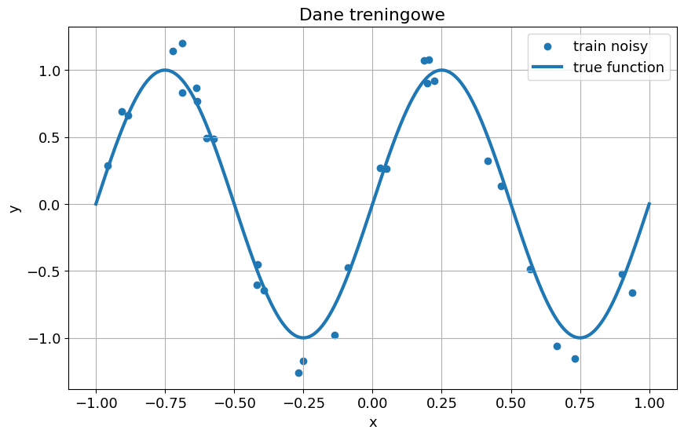

```python
# ============================================================
# GENEROWANIE DANYCH
# ============================================================

np.random.seed(RANDOM_SEED)

x_train = np.random.uniform(-1, 1, N_TRAIN)
x_test = np.linspace(-1, 1, N_TEST)

y_train_clean = np.sin(2 * np.pi * x_train)
y_test_clean = np.sin(2 * np.pi * x_test)

y_train = y_train_clean + NOISE_STD * np.random.randn(N_TRAIN)
y_test = y_test_clean + NOISE_STD * np.random.randn(N_TEST)

plt.scatter(x_train, y_train, label="train noisy")
plt.plot(x_test, y_test_clean, linewidth=3, label="true function")

plt.title("Dane treningowe")
plt.xlabel("x")
plt.ylabel("y")
plt.legend()
plt.grid()
plt.show()
```

```python
# ============================================================
# EKSPERYMENT REGRESYJNY
# ============================================================

degrees = list(range(1, MAX_DEGREE + 1))

train_mse = []
test_mse = []
nonzero_coefs = []
condition_numbers = []

start = time.time()

for d in degrees:

    X_train = make_design_matrix(x_train, d, POLY_BASIS)
    X_test = make_design_matrix(x_test, d, POLY_BASIS)

    condition_numbers.append(np.linalg.cond(X_train))

    if SCALE_FEATURES:
        scaler = StandardScaler()
        X_train_used = scaler.fit_transform(X_train)
        X_test_used = scaler.transform(X_test)
    else:
        X_train_used = X_train
        X_test_used = X_test

    model = make_model(
        REGULARIZER,
        alpha=ALPHA,
        l1_ratio=L1_RATIO
    )

    model.fit(X_train_used, y_train)

    pred_train = model.predict(X_train_used)
    pred_test = model.predict(X_test_used)

    train_mse.append(mean_squared_error(y_train, pred_train))
    test_mse.append(mean_squared_error(y_test, pred_test))
    nonzero_coefs.append(count_nonzero_coefficients(model))

elapsed = time.time() - start

print(f"Baza: {POLY_BASIS}")
print(f"Regularyzator: {REGULARIZER}")
print(f"Alpha: {ALPHA}")
print(f"Czas: {elapsed:.2f} s")
```

```
Baza: chebyshev
Regularyzator: ridge
Alpha: 0.001
Czas: 0.07 s
```

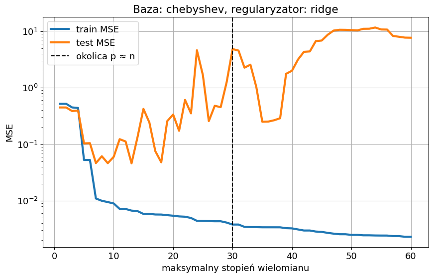

```python
# ============================================================
# WYKRES TRAIN / TEST ERROR
# ============================================================

plt.plot(degrees, train_mse, linewidth=3, label="train MSE")
plt.plot(degrees, test_mse, linewidth=3, label="test MSE")

plt.axvline(N_TRAIN, linestyle="--", color="black",
            label="okolica p ≈ n")

plt.yscale("log")

plt.xlabel("maksymalny stopień wielomianu")
plt.ylabel("MSE")
plt.title(f"Baza: {POLY_BASIS}, regularyzator: {REGULARIZER}")

plt.legend()
plt.grid()
plt.show()
```

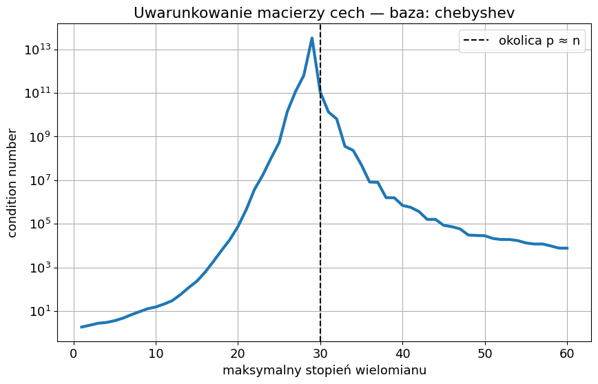

```python
# ============================================================
# WYKRES CONDITION NUMBER
# ============================================================

plt.plot(degrees, condition_numbers, linewidth=3)

plt.axvline(N_TRAIN, linestyle="--", color="black",
            label="okolica p ≈ n")

plt.yscale("log")

plt.xlabel("maksymalny stopień wielomianu")
plt.ylabel("condition number")
plt.title(f"Uwarunkowanie macierzy cech — baza: {POLY_BASIS}")

plt.legend()
plt.grid()
plt.show()
```

```python
# ============================================================
# SPARSITY DLA LASSO / ELASTICNET
# ============================================================

if REGULARIZER in ["lasso", "elasticnet"]:

    plt.plot(degrees, nonzero_coefs, linewidth=3, marker="o")

    plt.xlabel("maksymalny stopień wielomianu")
    plt.ylabel("liczba niezerowych współczynników")
    plt.title(f"Sparsity — {REGULARIZER}")

    plt.grid()
    plt.show()

else:
    print("Wykres sparsity ma sens głównie dla Lasso lub ElasticNet.")
```

```
Wykres sparsity ma sens głównie dla Lasso lub ElasticNet.
```

# Porównanie kilku baz i regularyzatorów jednym wykresem

Ta komórka pozwala szybko porównać wiele konfiguracji bez ręcznego zmieniania ustawień.

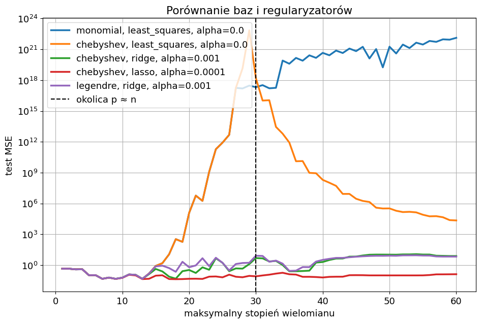

```
Czas porównania: 0.39 s
```

```python
# ============================================================
# PORÓWNANIE KONFIGURACJI
# ============================================================

configs = [
    ("monomial", "least_squares", 0.0),
    ("chebyshev", "least_squares", 0.0),
    ("chebyshev", "ridge", 1e-3),
    ("chebyshev", "lasso", 1e-4),
    ("legendre", "ridge", 1e-3),
]

plt.figure(figsize=(11, 7))

start = time.time()

for basis, regularizer, alpha in configs:

    errors = []

    for d in degrees:

        X_train = make_design_matrix(x_train, d, basis)
        X_test = make_design_matrix(x_test, d, basis)

        scaler = StandardScaler()
        X_train_used = scaler.fit_transform(X_train)
        X_test_used = scaler.transform(X_test)

        model = make_model(
            regularizer,
            alpha=alpha if alpha > 0 else ALPHA,
            l1_ratio=L1_RATIO
        )

        model.fit(X_train_used, y_train)
        pred_test = model.predict(X_test_used)

        errors.append(mean_squared_error(y_test, pred_test))

    label = f"{basis}, {regularizer}, alpha={alpha}"
    plt.plot(degrees, errors, linewidth=2.5, label=label)

plt.axvline(N_TRAIN, linestyle="--", color="black",
            label="okolica p ≈ n")

plt.yscale("log")
plt.xlabel("maksymalny stopień wielomianu")
plt.ylabel("test MSE")
plt.title("Porównanie baz i regularyzatorów")

plt.legend()
plt.grid()
plt.show()

print(f"Czas porównania: {time.time() - start:.2f} s")
```

## Pytania do studentów — część regresyjna

1. Która baza jest najlepiej uwarunkowana?
2. Dla której bazy interpolation peak jest największy?
3. Jak Ridge zmienia wykres błędu?
4. Jak Lasso zmienia liczbę aktywnych współczynników?
5. Czy Lasso zawsze generalizuje lepiej?
6. Czy duży model musi generalizować gorzej?

# CZĘŚĆ 2 — sieć neuronowa

Ta część jest celowo oddzielona od regresji wielomianowej.  
Sieć nadal rozwiązuje problem regresji, ale dostaje trudniejsze dane niż część wielomianowa.

Celem nie jest uzyskanie idealnego wykresu z podręcznika, tylko obserwacja:

- przejścia od underfittingu do overparameterization,
- wpływu szumu i uszkodzonych etykiet,
- różnicy między train error i test error,
- roli optimizera i weight decay.

Sieć:

```
1 → width → width → 1
```

Zmieniamy `width`, a więc liczbę parametrów.

```python
import torch
import torch.nn as nn
import torch.optim as optim

torch.manual_seed(RANDOM_SEED)
np.random.seed(RANDOM_SEED)
```

## Konfiguracja danych dla sieci

Używamy osobnych danych dla sieci neuronowej, bo pierwotny problem sinusoidalny był zbyt łatwy.  
Tutaj sygnał jest bardziej nieregularny, szum większy, a część etykiet może zostać celowo uszkodzona.

To wzmacnia różnicę między:

- modelem zbyt małym,
- modelem bliskim interpolacji,
- modelem silnie overparameterized.

```python
# ============================================================
# KONFIGURACJA DANYCH DLA SIECI NEURONOWEJ
# ============================================================

NN_N_TRAIN = 18
NN_N_TEST = 1000

NN_NOISE_STD = 0.35

LABEL_CORRUPTION = 0.25
# odsetek celowo uszkodzonych etykiet treningowych;
# ustaw 0.0, aby wyłączyć ten efekt

NN_RANDOM_SEED = 123
```

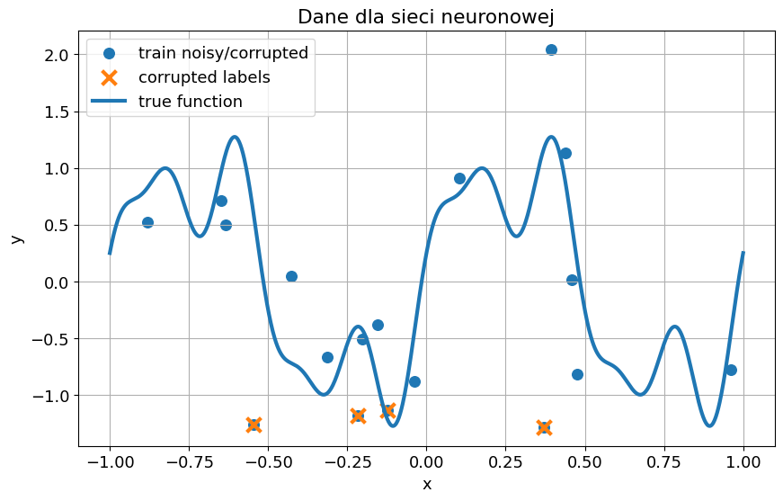

```
NN_N_TRAIN = 18
NN_NOISE_STD = 0.35
Liczba uszkodzonych etykiet = 4
```

```python
# ============================================================
# GENEROWANIE DANYCH DLA SIECI
# ============================================================

np.random.seed(NN_RANDOM_SEED)
torch.manual_seed(NN_RANDOM_SEED)

x_train_nn_np = np.random.uniform(-1, 1, NN_N_TRAIN)
x_test_nn_np = np.linspace(-1, 1, NN_N_TEST)

def nn_true_function(x):
    return (
        np.sin(2 * np.pi * x)
        + 0.45 * np.sin(6 * np.pi * x)
        + 0.25 * np.cos(10 * np.pi * x)
    )

y_train_nn_clean = nn_true_function(x_train_nn_np)
y_test_nn_clean = nn_true_function(x_test_nn_np)

y_train_nn_np = y_train_nn_clean + NN_NOISE_STD * np.random.randn(NN_N_TRAIN)
y_test_nn_np = y_test_nn_clean + NN_NOISE_STD * np.random.randn(NN_N_TEST)

# Celowo psujemy część etykiet treningowych.
# To jest odpowiednik label noise / corrupted labels.
num_corrupted = int(LABEL_CORRUPTION * NN_N_TRAIN)
corrupted_idx = np.array([], dtype=int)

if num_corrupted > 0:
    corrupted_idx = np.random.choice(NN_N_TRAIN, size=num_corrupted, replace=False)
    y_train_nn_np[corrupted_idx] = np.random.uniform(
        low=np.min(y_train_nn_clean) - 1.0,
        high=np.max(y_train_nn_clean) + 1.0,
        size=num_corrupted
    )

plt.scatter(x_train_nn_np, y_train_nn_np, s=70, label="train noisy/corrupted")

if num_corrupted > 0:
    plt.scatter(
        x_train_nn_np[corrupted_idx],
        y_train_nn_np[corrupted_idx],
        s=130,
        marker="x",
        linewidths=3,
        label="corrupted labels"
    )

plt.plot(x_test_nn_np, y_test_nn_clean, linewidth=3, label="true function")
plt.title("Dane dla sieci neuronowej")
plt.xlabel("x")
plt.ylabel("y")
plt.legend()
plt.grid()
plt.show()

print(f"NN_N_TRAIN = {NN_N_TRAIN}")
print(f"NN_NOISE_STD = {NN_NOISE_STD}")
print(f"Liczba uszkodzonych etykiet = {num_corrupted}")
```

```python
# ============================================================
# KONWERSJA DO PYTORCH
# ============================================================

x_train_nn = torch.tensor(x_train_nn_np.reshape(-1, 1), dtype=torch.float32)
y_train_nn = torch.tensor(y_train_nn_np.reshape(-1, 1), dtype=torch.float32)

x_test_nn = torch.tensor(x_test_nn_np.reshape(-1, 1), dtype=torch.float32)
y_test_nn = torch.tensor(y_test_nn_np.reshape(-1, 1), dtype=torch.float32)

y_test_clean_tensor = torch.tensor(y_test_nn_clean.reshape(-1, 1), dtype=torch.float32)
```

```python
class SmallNet(nn.Module):

    def __init__(self, width):

        super().__init__()

        self.net = nn.Sequential(
            nn.Linear(1, width),
            nn.Tanh(),
            nn.Linear(width, width),
            nn.Tanh(),
            nn.Linear(width, 1)
        )

    def forward(self, x):
        return self.net(x)


def count_params(model):
    return sum(p.numel() for p in model.parameters())
```

## Konfiguracja treningu sieci

Najważniejsze parametry do eksperymentów:

- `WIDTHS` — szerokość sieci, czyli pośrednio liczba parametrów,
- `EPOCHS` — liczba epok,
- `OPTIMIZER` — `"adam"` albo `"sgd"`,
- `WEIGHT_DECAY` — jawna regularyzacja L2.

```python
# ============================================================
# KONFIGURACJA SIECI
# ============================================================

WIDTHS = [
    1, 2, 3, 4, 5, 6, 8, 10, 12,
    16, 20, 24, 32, 48, 64,
    96, 128, 192, 256, 384, 512
]

EPOCHS = 4000
LEARNING_RATE = 0.01
WEIGHT_DECAY = 0.0

OPTIMIZER = "sgd"
# opcje: "adam", "sgd"

SHOW_EVERY = 0
# 0 = bez wypisywania postępu
```

```python
# ============================================================
# EKSPERYMENT NN
# ============================================================

train_errors_nn = []
test_errors_nn = []
test_clean_errors_nn = []
num_params_nn = []

saved_predictions = {}

widths_to_plot = [2, 8, 32, 128, 512]

start = time.time()

for width in WIDTHS:

    torch.manual_seed(NN_RANDOM_SEED)

    model = SmallNet(width)

    if OPTIMIZER == "adam":
        optimizer = optim.Adam(
            model.parameters(),
            lr=LEARNING_RATE,
            weight_decay=WEIGHT_DECAY
        )

    elif OPTIMIZER == "sgd":
        optimizer = optim.SGD(
            model.parameters(),
            lr=LEARNING_RATE,
            momentum=0.9,
            weight_decay=WEIGHT_DECAY
        )

    else:
        raise ValueError("OPTIMIZER musi być 'adam' albo 'sgd'.")

    loss_fn = nn.MSELoss()

    for epoch in range(EPOCHS):

        optimizer.zero_grad()
        pred = model(x_train_nn)
        loss = loss_fn(pred, y_train_nn)
        loss.backward()
        optimizer.step()

    with torch.no_grad():

        train_pred = model(x_train_nn)
        test_pred = model(x_test_nn)

        train_mse = loss_fn(train_pred, y_train_nn).item()
        test_mse = loss_fn(test_pred, y_test_nn).item()
        test_clean_mse = loss_fn(test_pred, y_test_clean_tensor).item()

        if width in widths_to_plot:
            saved_predictions[width] = test_pred.numpy().ravel()

    train_errors_nn.append(train_mse)
    test_errors_nn.append(test_mse)
    test_clean_errors_nn.append(test_clean_mse)
    num_params_nn.append(count_params(model))

    if SHOW_EVERY and width % SHOW_EVERY == 0:
        print(width, train_mse, test_mse)

print(f"Czas NN: {time.time() - start:.2f} s")
```

```
Czas NN: 14.04 s
```

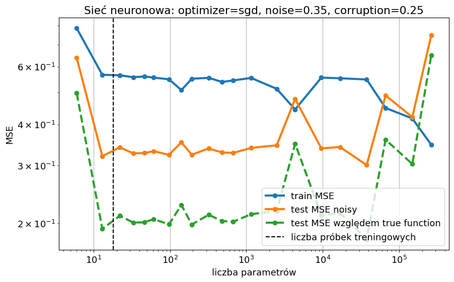

```python
# ============================================================
# WYKRES TRAIN / TEST ERROR
# ============================================================

plt.plot(num_params_nn, train_errors_nn, marker="o",
         linewidth=3, label="train MSE")

plt.plot(num_params_nn, test_errors_nn, marker="o",
         linewidth=3, label="test MSE noisy")

plt.plot(num_params_nn, test_clean_errors_nn, marker="o",
         linewidth=3, linestyle="--", label="test MSE względem true function")

plt.axvline(NN_N_TRAIN, linestyle="--", color="black",
            label="liczba próbek treningowych")

plt.xscale("log")
plt.yscale("log")

plt.xlabel("liczba parametrów")
plt.ylabel("MSE")
plt.title(
    f"Sieć neuronowa: optimizer={OPTIMIZER}, "
    f"noise={NN_NOISE_STD}, corruption={LABEL_CORRUPTION}"
)

plt.legend()
plt.grid()
plt.show()
```

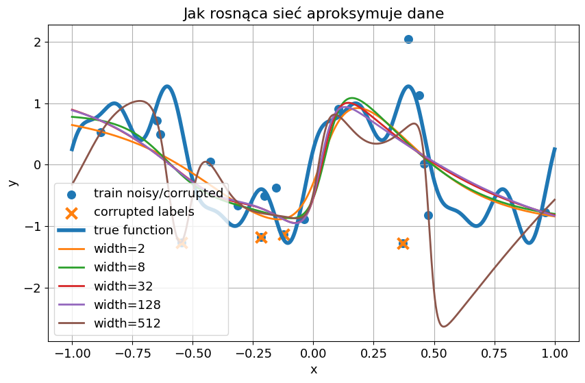

```python
# ============================================================
# WYKRES PREDYKCJI DLA WYBRANYCH SZEROKOŚCI
# ============================================================

plt.scatter(x_train_nn_np, y_train_nn_np, s=70, label="train noisy/corrupted")

if num_corrupted > 0:
    plt.scatter(
        x_train_nn_np[corrupted_idx],
        y_train_nn_np[corrupted_idx],
        s=130,
        marker="x",
        linewidths=3,
        label="corrupted labels"
    )

plt.plot(x_test_nn_np, y_test_nn_clean, linewidth=4, label="true function")

for width, pred in saved_predictions.items():
    plt.plot(x_test_nn_np, pred, linewidth=2, label=f"width={width}")

plt.title("Jak rosnąca sieć aproksymuje dane")
plt.xlabel("x")
plt.ylabel("y")
plt.legend()
plt.grid()
plt.show()
```

## Jak interpretować tę część?

Jeżeli wykres nadal nie pokazuje idealnego double descent, to nie jest porażka eksperymentu.  
To jest uczciwa obserwacja: w małych sieciach 1D double descent bywa słaby i zależy od danych, szumu, optimizera, liczby epok oraz inicjalizacji.

Najważniejsze pytanie dla studentów brzmi:

> Dlaczego train error może maleć monotonicznie, a test error zachowuje się niemonotonicznie?

To wymusza rozmowę o:

- overfittingu,
- szumie,
- interpolacji,
- regularyzacji jawnej i niejawnej,
- roli optimizera.

# Zadania dla studentów

## Regresja

1. Porównaj:
   - `monomial`,
   - `chebyshev`,
   - `legendre`.
2. Porównaj:
   - `least_squares`,
   - `ridge`,
   - `lasso`,
   - `elasticnet`.
3. Sprawdź wpływ `ALPHA`.
4. Sprawdź, kiedy Lasso wybiera mało współczynników.
5. Zinterpretuj wykres condition number.

## Pytania pomocnicze (nie wymagające pisemnej odpowiedzi!)

1. Czy wybór bazy wpływa na generalizację?
2. Czy regularyzacja zawsze pomaga?
3. Czy sparse model zawsze jest lepszy?
4. Czy overparameterization musi oznaczać overfitting?
5. Jaka jest różnica między regularizacją jawną i niejawną?

# UZASADNIJ (WYMAGA pisemnej odpowiedzi)

1. Czy interpolation peak jest przede wszystkim zjawiskiem statystycznym czy numerycznym? Przedyskutuj problem na podstawie eksperymentów z różnymi bazami i regularyzatorami.
2. Dlaczego silnie overparameterized sieć neuronowa może generalizować lepiej niż model bliski interpolation threshold, mimo że posiada znacznie więcej parametrów niż danych?

## ODPOWIEDZI NA TE PYTANIA wymagają odniesienia do konkretnych wykresów z notebooka.

# Odpowiedzi